# CNV Frequency in Glioblastoma

Noelia Rodriguez Carballo

2023-09-27

## Tumor Information

Glioblastomas are a type of glioma, which means it is a cancer that affects the glial cells. Glial cells play a crucial role in the nervous system, stabilazing, nurturing and insulating neurons. Glioblastomas usually form in the white matter of the brain and can grow very quickly causing headaches, nausea, seizures, memory loss and changes in personality and behaviour. This type of cancer is the most common and also most lethal with a poor prognosis of survival with its origin in the brain. Tumors are categorized in two types depending on whether there are mutations in isocitarte dehydrogenase 1 or not.

The NCIt code is C3058

## Access the CNV frequency data

### Load library

```r
library(pgxRpi)
```

### Access data

```r
freq <- pgxLoader(type='frequency',output= 'pgxfreq',filters="NCIT:C3058")
```

The metadata information is:

```r
freq$meta
```

```
##         code        label sample_count
## 1 NCIT:C3058 Glioblastoma         4384
## 2      total                      4384
```

The data looks like this:

```r
freq$data$`NCIT:C3058`[c(1:3),]
```

```
##      filters reference_name   start     end gain_frequency loss_frequency no
## 1 NCIT:C3058              1       0  400000          3.672          3.604  1
## 2 NCIT:C3058              1  400000 1400000          9.991          6.090  2
## 3 NCIT:C3058              1 1400000 2400000         12.500          7.961  3
```

## Visualization

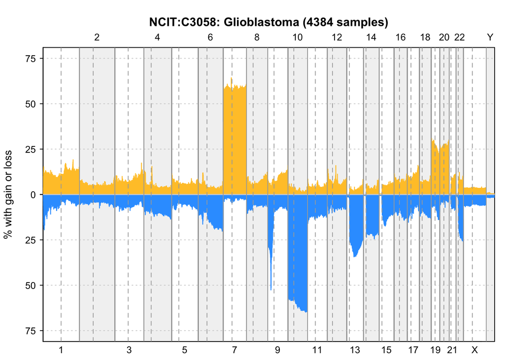

```r
pgxFreqplot(freq)
```

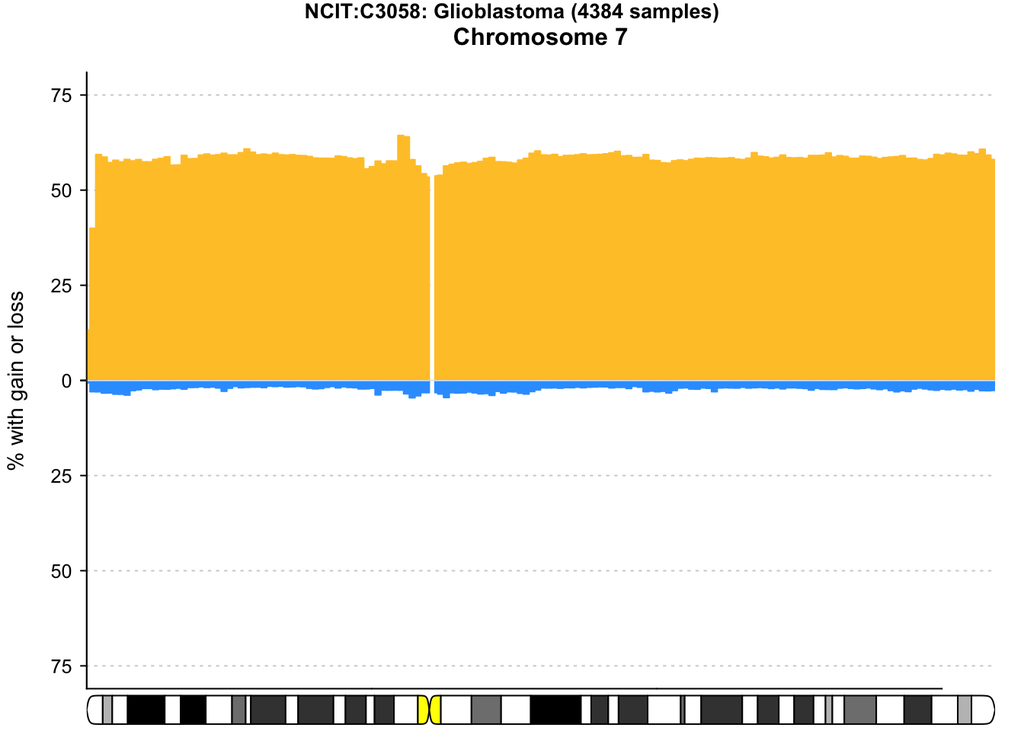

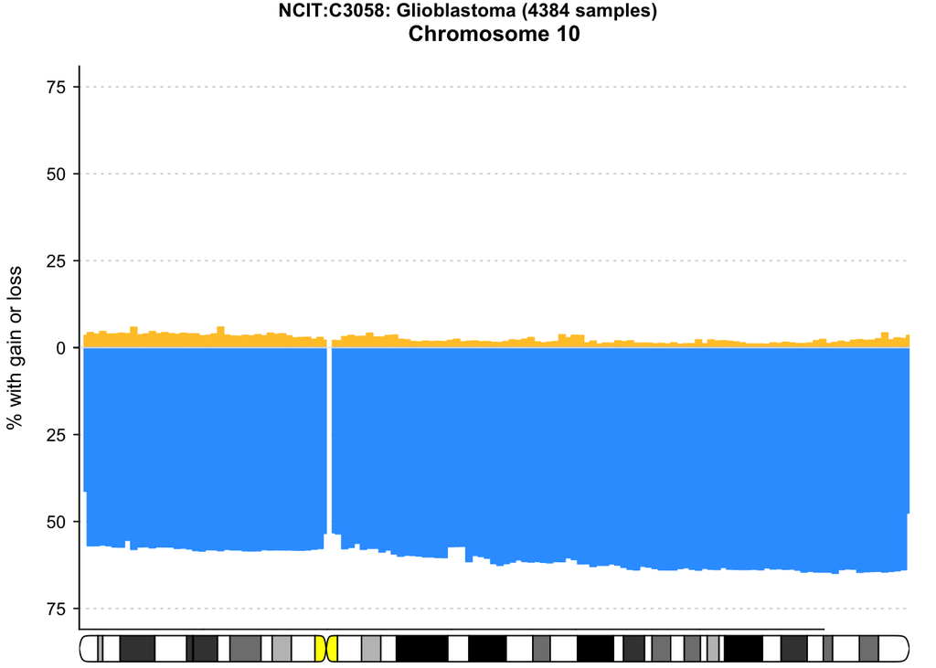

```r
pgxFreqplot(freq, chrom=c(7,10))
```

## Analysis

According to the plot, the most frequent duplications are on chromosomes 7p, 7q and the most frequent deletions on chromosomes 10p,10q. (50% as a cut-off) Other frequent duplications are on chromosomes 19p, 19q, 20p, 20q and deletions on chromosomes 9p, 13q. (25% as a cut-off) One [study](https://www.sciencedirect.com/science/article/pii/S0046817718304970) detected frequent duplication in chromosomes 7p, 7q, 19p, 19q, 20p, 20q and frequent deletion in chromosomes 9p, 10p, 10q, 13, 14. There are overlaps: 7p, 7q, 19p, 19q, 20p, 20q for duplication; 9p, 10p, 10q, 13q for deletion.

This study suggests that the amplification of EGFR correlating with the polysomy of chromosome 7, 19 and 20 and the loss of the tumor supressor PTEN could be related to tumorigenisis. The increased number of EGF receptors that could be caused by this amplification can partially explain the appearance of the tumor. Even though the growth signal stays constant, the cell’s reaction will be exaggerated and might grow incontrollably. The loss of the tumor supressor PTEN facilitates this as it cannot serve as a control. Assesment of the these variations are not clinically relevant, however, as they do not help to conclude on the type of therapy to use nor the survival rate.